# Predicting Correct Weightlifting Form

Alex Robinson

30 January 2018

## Summary

Using data from the Human Activity Recognition project (http://groupware.les.inf.puc-rio.br/har) this exploration looks to predict whether a lift was performed correctly based on activity data.

## Cross Validation

80% of the data will be extracted for use in the exploratory analysis and initial model fitting.

The remaining 20% will be used for testing the trained model with the reserved 20 test cases used as final validation.

```r
inTrain <- createDataPartition(y=training.all$classe, p = 0.8, list = FALSE)
# assign 80% of the data to training
training <- training.all[inTrain,]
testing <- training.all[-inTrain,]
```

## Exploratory Analysis

Looking at the training data set it’s worth setting some baselines for any prediction algorithm.

With 5 classes of movement (A-E) random guessing would have a 1 in 5 (20%) chance of success. Always predicting that the movement was successfully performed would improve this to 28% because there are a slightly higher proportion of succesfully performed movements.

Investigating further not all the telemetry values have complete information within the data frame but the yaw, pitch and roll values for the main sensors seem potentially interesting.

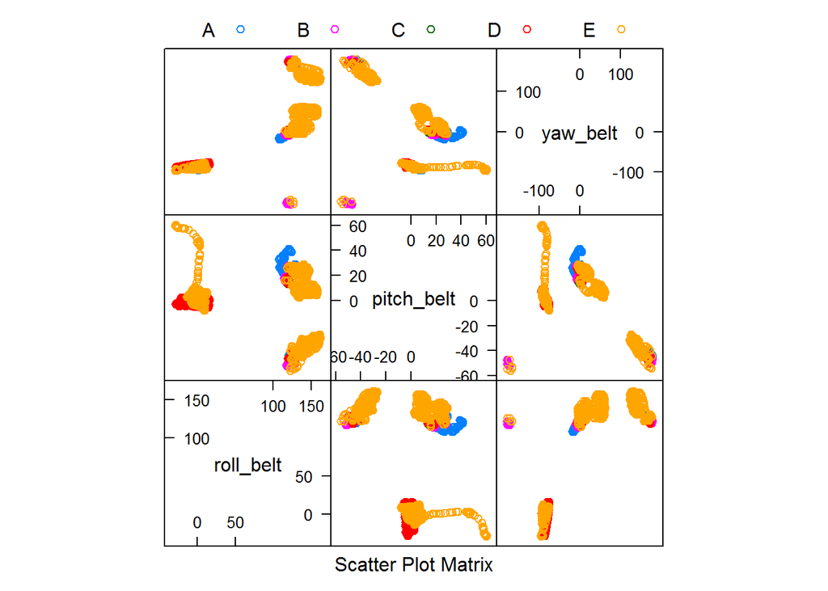

```r
ptn <- "^(roll|pitch|yaw)_(arm|belt|dumbbell|forearm)$"
ptn_belt <- "^(roll|pitch|yaw)_belt$"
# extract all column names for the pitch, yaw, roll telemetry for
# the arm, belt, dumbbell and forearm sensors
all_cols <- names(training)[grep(ptn, names(training))]
# subset out the belt sensor telemetry for an example plot
belt_cols <-  names(training)[grep(ptn_belt, names(training))]

featurePlot(x = training[,belt_cols], y = training$classe, plot = "pairs",
            auto.key = list(columns = 5))
```

Figure 1 - Pairwise plot of belt sensor telemetry

Above is an example of a feature plot of a subset of data, already the pitch_belt telemetry seems helpful in identifying the “E” class of incorrect movements.

## Fitting a Model and Prediction

The challenge calls for classifying the telemetry readings into 1 of 5 outcomes, this seems to suggest that a classification and regression tree (CART) model may be best suited to the task.

To improve accuracy a bootstrap aggregation (bagging) approach will be used.

```r
modelFit <- train(x = training[, all_cols], y = training$classe,
                  method = "treebag")
```

We can then use this model to explore the in sample and out of sample error with the training and test sets.

```r
# in sample error predicting against training set
predIn <- predict(modelFit, training)
inSample <- percent(1 - mean(predIn == training$classe))
# out of sample error, predicting against testing set
predOut <- predict(modelFit, testing)
outSample <- percent(1 - mean(predOut == testing$classe))
# tabulation of whether prediction matches the training observed behaviour
table(predIn == training$classe)
```

```
##
##  TRUE
## 15699
```

```r
# tabulation of whether prediction matches the TESTING observed behaviour
table(predOut == testing$classe)
```

```
##
## FALSE  TRUE
##    57  3866
```

So the in sample error is 0% and out of sample is 1.45%.

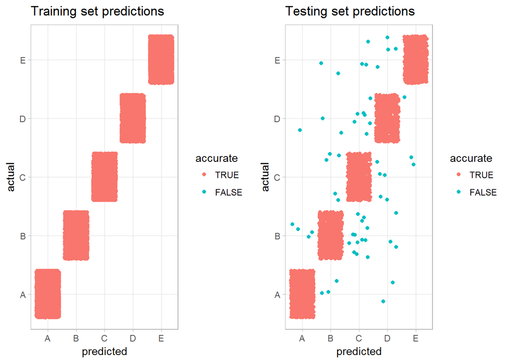

Figure 2 - Visualisation of prediction accuracy

Clearly the prediction is somewhat overfitted to the training set but the suggested out of sample error rate is low indicating a good model.

## Validation

The model having been trained and tested can now be applied to the validation set with some expectation of accuracy.

```r
# The model can now be applied to the 20 cases of the validation set
predVal <- predict(modelFit, validation)
# which gives the following predictions for submission
predVal
```

```
##  [1] B A B A A E D B A A B C B A E E A B B B
## Levels: A B C D E
```